# R Basics Homework

Ian Rolfe

1/17/2023

## Reading in the Data

```r
tgpp <- read.csv("./tgpp.csv", header = TRUE)

tgpp <- read.csv('https://raw.githubusercontent.com/dmcglinn/quant_methods/gh-pages/data/tgpp.csv', header = T)
```

## Vieiwng Data

```r
head(tgpp)
```

```
##   plot year record_id corner scale richness easting northing slope  ph yrsslb
## 1  205 1998       187     NA   100       60  727000  4080000     3 6.9   0.39
## 2  205 1998       188      1    10       36  727000  4080000     3 6.9   0.39
## 3  205 1998       189      2    10       34  727000  4080000     3 6.9   0.39
## 4  205 1998       190      3    10       37  727000  4080000     3 6.9   0.39
## 5  205 1998       191      4    10       33  727000  4080000     3 6.9   0.39
## 6  205 1998       192      1     1       21  727000  4080000     3 6.9   0.39
```

```r
summary(tgpp)
```

```
##       plot            year        record_id        corner         scale
##  Min.   :205.0   Min.   :1998   Min.   : 187   Min.   :1.00   Min.   :  0.010
##  1st Qu.:225.0   1st Qu.:2001   1st Qu.:1207   1st Qu.:1.75   1st Qu.:  0.100
##  Median :281.0   Median :2004   Median :2226   Median :2.50   Median :  1.000
##  Mean   :275.8   Mean   :2004   Mean   :2226   Mean   :2.50   Mean   :  8.496
##  3rd Qu.:317.5   3rd Qu.:2006   3rd Qu.:3246   3rd Qu.:3.25   3rd Qu.: 10.000
##  Max.   :350.0   Max.   :2009   Max.   :4266   Max.   :4.00   Max.   :100.000
##                                                NA's   :240
##     richness         easting          northing           slope
##  Min.   :  0.00   Min.   :727000   Min.   :4069000   Min.   :1.00
##  1st Qu.:  7.00   1st Qu.:729750   1st Qu.:4074750   1st Qu.:2.00
##  Median : 18.00   Median :731000   Median :4078500   Median :3.50
##  Mean   : 24.38   Mean   :731550   Mean   :4078000   Mean   :3.55
##  3rd Qu.: 37.00   3rd Qu.:734000   3rd Qu.:4080250   3rd Qu.:5.00
##  Max.   :104.00   Max.   :738000   Max.   :4086000   Max.   :8.00
##
##        ph            yrsslb
##  Min.   :5.500   Min.   : 0.150
##  1st Qu.:6.000   1st Qu.: 0.250
##  Median :6.200   Median : 1.240
##  Mean   :6.333   Mean   : 2.079
##  3rd Qu.:6.700   3rd Qu.: 3.212
##  Max.   :7.600   Max.   :11.220
##
```

## 1. What are the names of the columns in this dataset?

*The column names are “plot”, “year”, “record_id”, “corner”, “scale”, “richness”, “easting”, “northing”, “slope”, “ph”, “yrsslb”* *We know this from “names(tgpp)*

```r
names(tgpp)
```

```
##  [1] "plot"      "year"      "record_id" "corner"    "scale"     "richness"
##  [7] "easting"   "northing"  "slope"     "ph"        "yrsslb"
```

## 2. How many rows and columns does this data file have?

*This file has 4080 rows and 11 columns* *We know this from dim(tgpp)*

```r
dim(tgpp)
```

```
## [1] 4080   11
```

## 3. What kind of object is each data column?

*Using sapply() to apply the class() function to all columns in “tgpp”. This finds the class of each object in “tgpp”*

```r
sapply(tgpp, class)
```

```
##      plot      year record_id    corner     scale  richness   easting  northing
## "integer" "integer" "integer" "integer" "numeric" "integer" "integer" "integer"
##     slope        ph    yrsslb
## "integer" "numeric" "numeric"
```

## 4. What are the values of the datafile for the rows 1,5,8 at columns 3,7,10?

*We’ll use the brackets[] to find these values below* *rows always are input before columns, so we will use the code tgpp[c(1,5,8), c(3,7,10)]* *Creates a 3x3 matrix of data*

```r
tgpp[c(1,5,8), c(3,7,10)]
```

```
##   record_id easting  ph
## 1       187  727000 6.9
## 5       191  727000 6.9
## 8       194  727000 6.9
```

## 5. Create a pdf of the relationship between “scale” and “richness”.

*We’ll create this by using the plot function, with “scale” as our X and “richness” as our Y* *Then we’ll add nice colors using “col =”blue”“* pdf(./R_Homework_fig.pdf) to save the figure as a pdf file

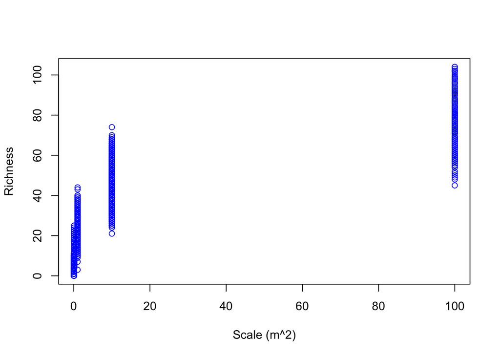

```r
plot(richness ~ scale, data = tgpp, xlab = "Scale (m^2)", ylab = "Richness", col = "blue")
```

## 6. What happens to your plot when you set the plot argument log equal to ‘xy’?

*By setting the plot argument log = ‘xy’, you are telling R to have both the x and y axis be logarithmic*

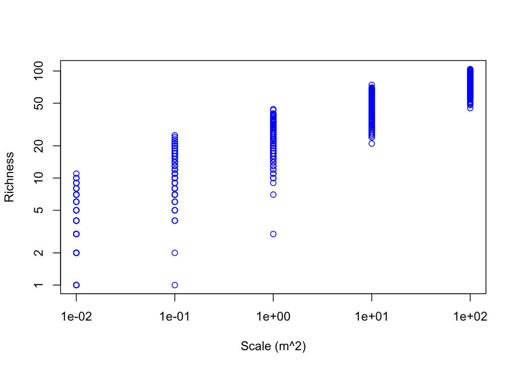

```r
plot(richness ~ scale, data = tgpp, xlab = "Scale (m^2)", ylab = "Richness", col = "blue", log = "xy")
```